**City College of San Francisco**

MATH 108 - Foundations of Data Science

# Lecture 35: Residuals

Associated Textbook Sections: [15.5 - 15.6](https://inferentialthinking.com/chapters/15/5/Visual_Diagnostics.html)

## Outline

- Residuals
- Regression Diagnostics
- A Measure of Clustering

## Set Up the Notebook

```python
from datascience import *
import numpy as np
%matplotlib inline
import matplotlib.pyplot as plt
plt.style.use('fivethirtyeight')

# Functions defined in previous lectures

def standard_units(arr):
    """ Converts an array to standard units """
    return (arr - np.average(arr))/np.std(arr)

def correlation(t, x, y):
    """ Computes correlation: t is a table, and x and y are column names """
    x_standard = standard_units(t.column(x))
    y_standard = standard_units(t.column(y))
    return np.average(x_standard * y_standard)

def slope(t, x, y):
    """ Computes the slope of the regression line, like correlation above """
    r = correlation(t, x, y)
    y_sd = np.std(t.column(y))
    x_sd = np.std(t.column(x))
    return r * y_sd / x_sd

def intercept(t, x, y):
    """ Computes the intercept of the regression line, like slope above """
    x_mean = np.mean(t.column(x))
    y_mean = np.mean(t.column(y))
    return y_mean - slope(t, x, y)*x_mean

def fitted_values(t, x, y):
    """Return an array of the regression estimates (predictions) at all the x values"""
    a = slope(t, x, y)
    b = intercept(t, x, y)
    return a*t.column(x) + b
```

## Residuals

### Residuals

- Error in regression estimate
- One residual corresponding to each point (x, y)
- residual
  - = observed y - regression estimate of y
  - = observed y - height of regression line at x
  - = vertical distance between the point and the best line

### Demo: Residuals

Calculate and visualize the residuals associated with linear regression estimates for `Median Income` values based on `College%` in the `district_demographics2016.csv` data.

```python
demographics = Table.read_table('data/district_demographics2016.csv')
demographics
```

| State | District | Median Income | College% |
| --- | --- | --- | --- |
| Alabama | Congressional District 1 (115th Congress), Alabama | 47083 | 24 |
| Alabama | Congressional District 2 (115th Congress), Alabama | 42035 | 21.8 |
| Alabama | Congressional District 3 (115th Congress), Alabama | 46544 | 22.8 |
| Alabama | Congressional District 4 (115th Congress), Alabama | 41110 | 17 |
| Alabama | Congressional District 5 (115th Congress), Alabama | 51690 | 30.3 |
| Alabama | Congressional District 6 (115th Congress), Alabama | 61413 | 36.7 |
| Alabama | Congressional District 7 (115th Congress), Alabama | 34664 | 19.4 |
| Alaska | Congressional District (at Large) (115th Congress), Alaska | 76440 | 29.6 |
| Arizona | Congressional District 1 (115th Congress), Arizona | 50537 | 24.5 |
| Arizona | Congressional District 2 (115th Congress), Arizona | 49072 | 34 |

... (425 rows omitted)

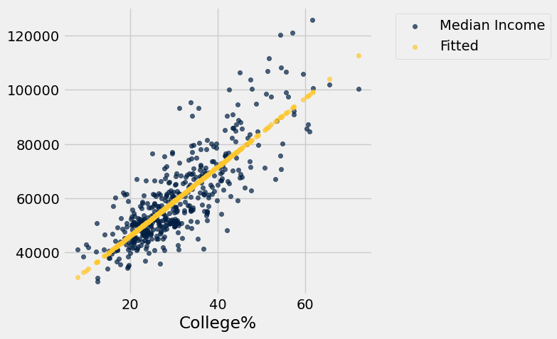

```python
predict_income = demographics.select('College%', 'Median Income')
predict_income = predict_income.with_columns('Fitted',
    fitted_values(demographics, 'College%', 'Median Income'))
predict_income.scatter('College%')
```

```python
demographics = demographics.drop(
    'State', 'District')
demographics.show(5)
```

| Median Income | College% |
| --- | --- |
| 47083 | 24 |
| 42035 | 21.8 |
| 46544 | 22.8 |
| 41110 | 17 |
| 51690 | 30.3 |

... (430 rows omitted)

```python
def residuals(t, x, y):
    predictions = fitted_values(t, x, y)
    return t.column(y) - predictions
```

```python
demographics = demographics.with_columns(
    'Fitted Value', fitted_values(demographics, 'College%', 'Median Income'),
    'Residual', residuals(demographics, 'College%', 'Median Income')
)
demographics
```

| Median Income | College% | Fitted Value | Residual |
| --- | --- | --- | --- |
| 47083 | 24 | 51299.4 | -4216.42 |
| 42035 | 21.8 | 48503.9 | -6468.87 |
| 46544 | 22.8 | 49774.6 | -3230.58 |
| 41110 | 17 | 42404.5 | -1294.51 |
| 51690 | 30.3 | 59304.8 | -7614.84 |
| 61413 | 36.7 | 67437.3 | -6024.33 |
| 34664 | 19.4 | 45454.2 | -10790.2 |
| 76440 | 29.6 | 58415.3 | 18024.7 |
| 50537 | 24.5 | 51934.8 | -1397.77 |
| 49072 | 34 | 64006.4 | -14934.4 |

... (425 rows omitted)

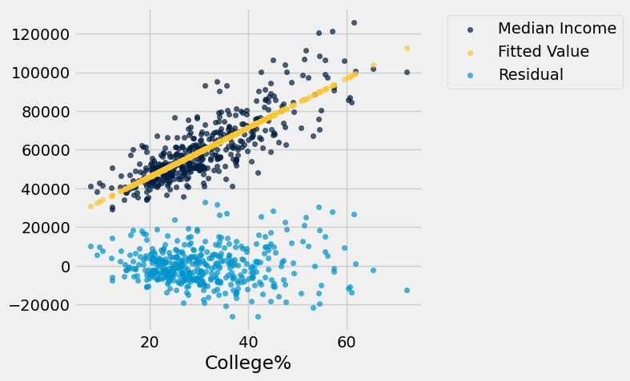

```python
demographics.scatter('College%')
```

```python
def plot_residuals(t, x, y):      # plots scatter plot of data and fitted together, then plots the residual plot underneath
    tbl = t.with_columns(
        'Fitted', fitted_values(t, x, y),
        'Residual', residuals(t, x, y)
    )
    tbl.select(x, y, 'Fitted').scatter(0)
    tbl.scatter(x, 'Residual')
```

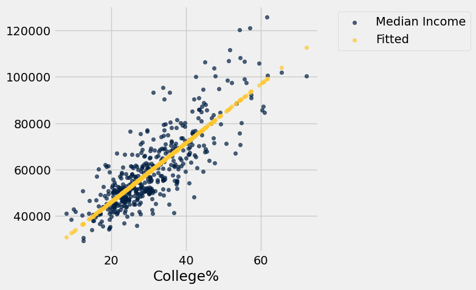

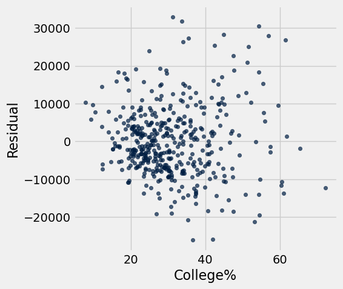

```python
plot_residuals(demographics, 'College%', 'Median Income')
```

Additionally, visualize the residuals associated with the `galton.csv` data set when predicting `Child` values from `Midparent` values using linear regression.

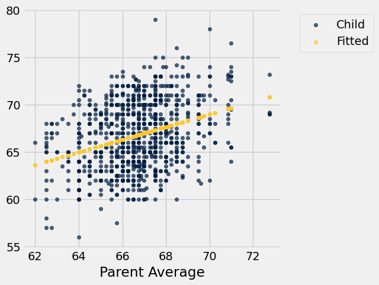

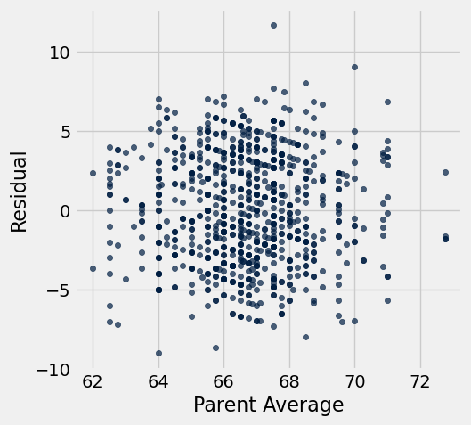

```python
family_heights = Table.read_table('data/family_heights.csv')
parents = (family_heights.column('father') + family_heights.column('mother'))/2
heights = Table().with_columns(
    'Parent Average', parents,
    'Child', family_heights.column('childHeight')
    )
plot_residuals(heights, 'Parent Average', 'Child')
```

## Regression Diagnostics

### Example: Dugongs

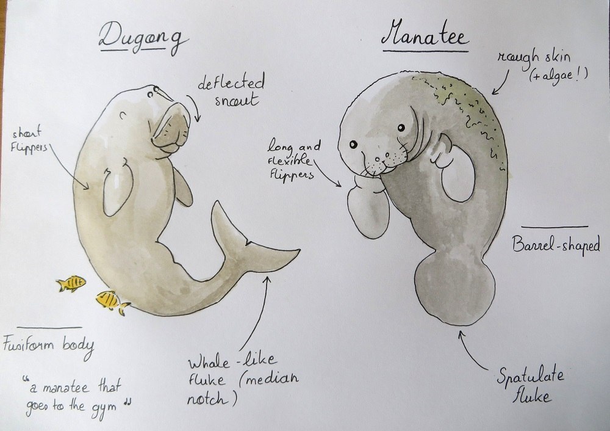

Image Source: [OSU Geospatial Ecology of Marine Megafauna Laboratory](https://blogs.oregonstate.edu/gemmlab/2021/09/27/let-me-introduce-you-to-dugongs/)

### Demo: Dugongs

Visualize the relationship between a dugong's length and age based on the `dugong.csv` dataset. Although the data is not linear, calculate the correlation coefficient.

```python
dugong = Table.read_table('data/dugong.csv')
dugong.show(5)
```

| Length | Age |
| --- | --- |
| 1.8 | 1 |
| 1.85 | 1.5 |
| 1.87 | 1.5 |
| 1.77 | 1.5 |
| 2.02 | 2.5 |

... (22 rows omitted)

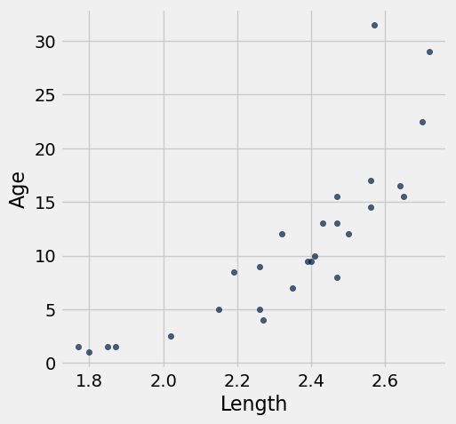

```python
dugong.scatter('Length', 'Age')
```

```python
correlation(dugong, 'Length', 'Age')
```

```
0.82964745549057139
```

Visualize the residuals associated with the linear regression prediction for a dugong's age based on it's height.

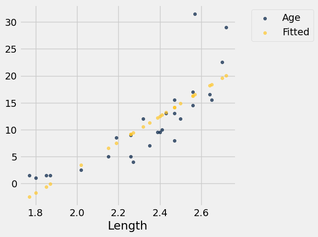

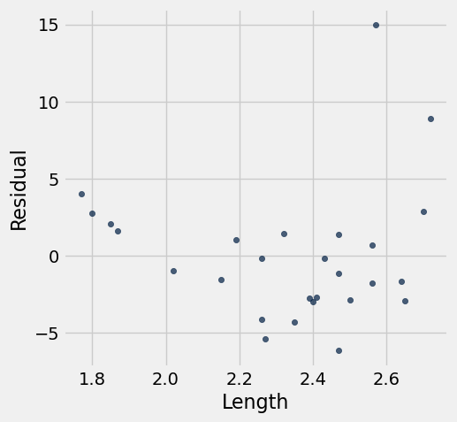

```python
plot_residuals(dugong, 'Length', 'Age')
```

### Demo: Us Women

```python
us_women = Table.read_table('data/us_women.csv')
us_women.show(5)
```

| height | ave weight |
| --- | --- |
| 58 | 115 |
| 59 | 117 |
| 60 | 120 |
| 61 | 123 |
| 62 | 126 |

... (10 rows omitted)

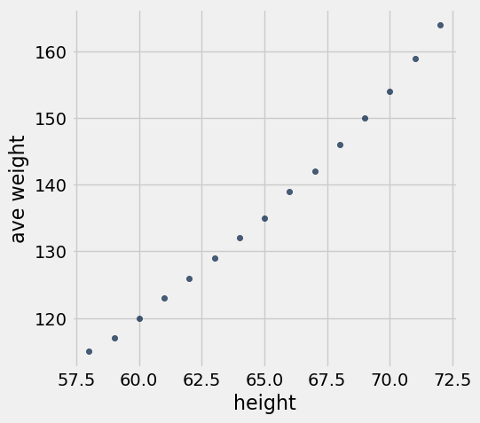

```python
us_women.scatter('height')
```

```python
correlation(us_women, 'height', 'ave weight')
```

```
0.99549476778421608
```

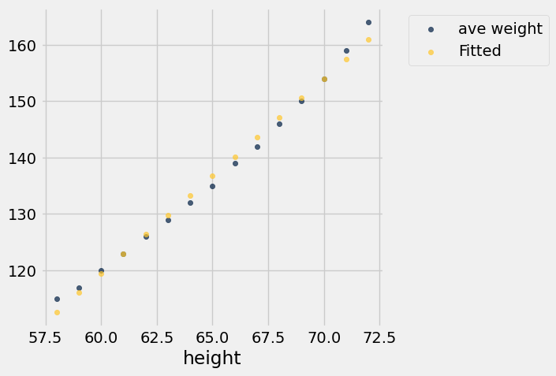

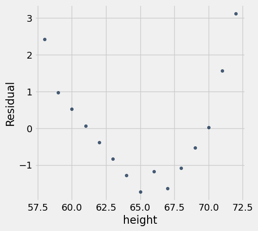

```python
plot_residuals(us_women, 'height', 'ave weight')
```

### Residual Plot

A scatter diagram of residuals

- Should look like an unassociated blob for linear relations
- But will show patterns for non-linear relations
- Used to check whether linear regression is appropriate
- Look for curves, trends, changes in spread, outliers, or any other patterns

### Properties of Residuals

Residuals from a linear regression always have

- Zero mean (so rmse = SD of residuals)
- Zero correlation with $x$
- Zero correlation with the fitted values

#### Demo: Properties of Residuals

```python
round(np.average(residuals(dugong, 'Length', 'Age')), 6)
```

```
0.0
```

```python
round(np.average(residuals(heights, 'Parent Average', 'Child')), 6)
```

```
0.0
```

```python
round(np.average(residuals(demographics, 'College%', 'Median Income')), 6)
```

```
0.0
```

```python
heights = heights.with_columns(
    'Residual', residuals(heights, 'Parent Average', 'Child'),
    'Fitted Value', fitted_values(heights, 'Parent Average', 'Child')
)
```

```python
round(correlation(heights, 'Parent Average', 'Residual'), 6)
```

```
0.0
```

```python
round(correlation(heights, 'Fitted Value', 'Residual'), 6)
```

```
0.0
```